# predictions for continuous models

Andrew

2022-03-12

## plotting models with two predictors

```r
library(palmerpenguins)
library(tidyverse)
library(lme4)
```

plot of the data

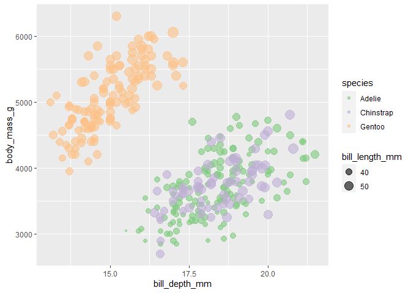

```r
penguins |>
  ggplot(aes(y = body_mass_g, x = bill_depth_mm, size = bill_length_mm, colour = species)) +
  geom_point(alpha = .6) +
  scale_colour_brewer(type = "qual")
```

predict body mass from the bill sizes

```r
mass_model <- lmer(body_mass_g ~ bill_depth_mm + bill_length_mm + (1|species), data = penguins)
summary(mass_model)
```

```
## Linear mixed model fit by REML ['lmerMod']
## Formula: body_mass_g ~ bill_depth_mm + bill_length_mm + (1 | species)
##    Data: penguins
##
## REML criterion at convergence: 4937
##
## Scaled residuals:
##     Min      1Q  Median      3Q     Max
## -2.3807 -0.6358 -0.0361  0.6369  3.2601
##
## Random effects:
##  Groups   Name        Variance Std.Dev.
##  species  (Intercept) 1104551  1051.0
##  Residual              112065   334.8
## Number of obs: 342, groups:  species, 3
##
## Fixed effects:
##                 Estimate Std. Error t value
## (Intercept)    -1415.530    685.440  -2.065
## bill_depth_mm    177.617     19.058   9.320
## bill_length_mm    55.986      7.216   7.758
##
## Correlation of Fixed Effects:
##             (Intr) bll_d_
## bll_dpth_mm -0.230
## bll_lngth_m -0.222 -0.526
```

Center the predictors

```r
penguin_centre <- penguins |>
  mutate(bill_d_c = bill_depth_mm - mean(bill_depth_mm, na.rm = TRUE),
         bill_l_c = bill_length_mm - mean(bill_length_mm, na.rm = TRUE))
```

```r
mass_model_c <- lmer(body_mass_g ~ bill_d_c + bill_l_c + (1|species), data = penguin_centre)
```

predictions and put on a figure

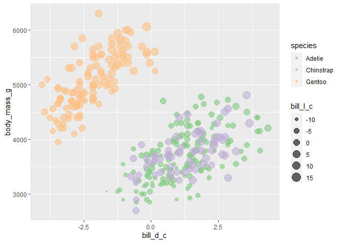

```r
peng_plot <- penguin_centre |>
  ggplot(aes(y = body_mass_g, x = bill_d_c, size = bill_l_c, colour = species)) +
  geom_point(alpha = .6) +
  scale_colour_brewer(type = "qual")

peng_plot
```

```r
library(modelr)

fake_penguins <- data_grid(penguin_centre,
          bill_d_c = seq_range(bill_d_c,n = 30),
          bill_l_c = seq_range(bill_l_c,n = 5),
          species)

fake_penguins$pred <- predict(mass_model_c, newdata = fake_penguins, type = "response")
```

add these to our plot

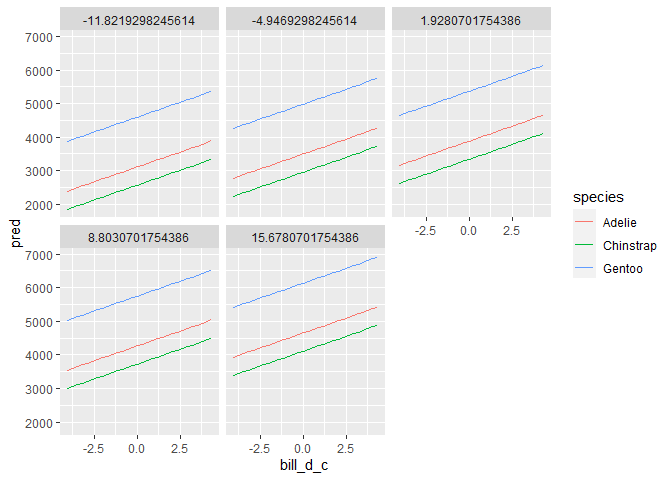

```r
fake_penguins |>
  ggplot(aes(x = bill_d_c, y = pred, colour = species)) + geom_line() + facet_wrap(~bill_l_c)
```

we get a jagged line between if we omit the other continuous variable

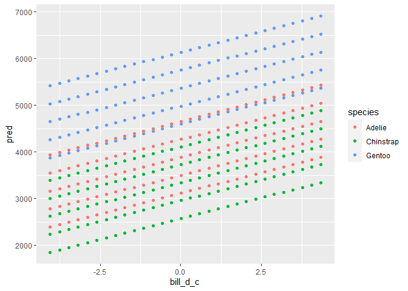

```r
fake_penguins |>
  ggplot(aes(x = bill_d_c, y = pred, colour = species)) + geom_point()
```

We can think of a model with two continuous predictors as representing a smooth 2 dimensional surface:

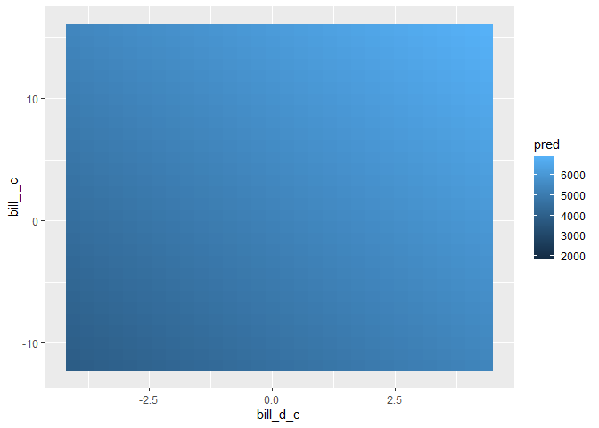

```r
more_fake_penguins <-  data_grid(penguin_centre,
          bill_d_c = seq_range(bill_d_c,n = 30),
          bill_l_c = seq_range(bill_l_c,n = 30),
          species)


more_fake_penguins$pred <- predict(mass_model_c, newdata = more_fake_penguins, type = "response")


more_fake_penguins |>
  ggplot(aes(x = bill_d_c, y = bill_l_c, fill = pred)) +
  geom_raster()
```

but this is too hard to visualize!

## Predicting for one at a time

Here we make two plots: one for bill depth, fixing length at the average. Then a second for bill length, fixing depth at the average

This is made easy by centering – we know the average is now 0

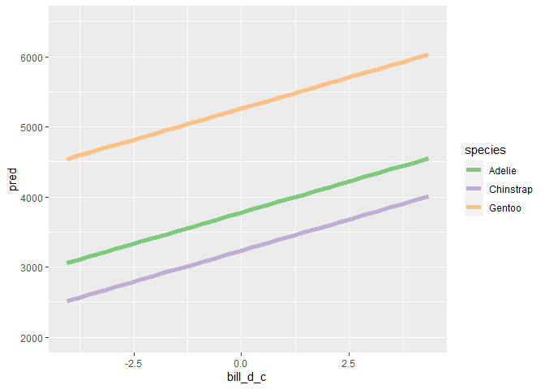

```r
fake_penguins_0_length <-
  data_grid(penguin_centre,
            bill_d_c = seq_range(bill_d_c,n = 30),
            bill_l_c = 0,
            species)


fake_penguins_0_length$pred <- predict(mass_model_c,
                                  newdata = fake_penguins_0_length, type = "response")

fake_penguins_0_length |>
  ggplot(aes(x = bill_d_c, y = pred, colour = species)) +
  geom_line(size = 2) +
  scale_colour_brewer(type = "qual") + coord_cartesian(ylim = c(2000, 6500))
```

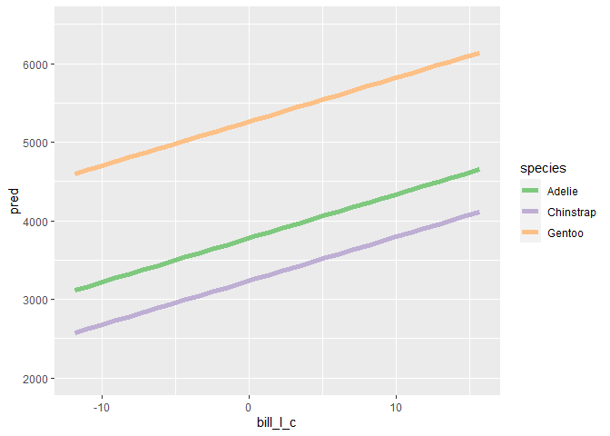

```r
fake_penguins_0_depth <-
  data_grid(penguin_centre,
            bill_d_c = 0,
            bill_l_c = seq_range(bill_l_c,n = 30),
            species)


fake_penguins_0_depth$pred <- predict(mass_model_c,
                                  newdata = fake_penguins_0_depth, type = "response")

fake_penguins_0_depth |>
  ggplot(aes(x = bill_l_c, y = pred, colour = species)) +
  geom_line(size = 2) +
  scale_colour_brewer(type = "qual")+ coord_cartesian(ylim = c(2000, 6500))
```

An alternative is to select only a few values for one predictor. This simplifies the figure and lets us understand the model more completely.

```r
# using cut to make a tryptich

range(penguin_centre$bill_l_c, na.rm = TRUE)
```

```
## [1] -11.82193  15.67807
```

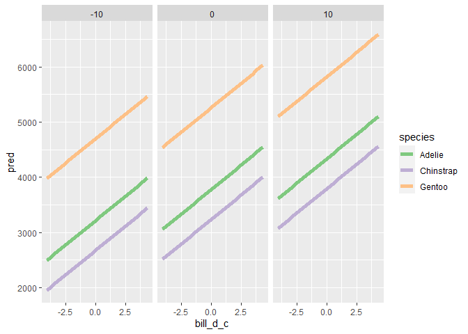

```r
fake_penguins_three_lengths <-
  data_grid(penguin_centre,
            bill_d_c = seq_range(bill_d_c,n = 30),
            bill_l_c = c(-10, 0, 10),
            species)


fake_penguins_three_lengths$pred <- predict(mass_model_c,
                                  newdata = fake_penguins_three_lengths, type = "response")

fake_penguins_three_lengths |>
  ggplot(aes(x = bill_d_c, y = pred, colour = species)) +
  geom_line(size = 2) +
  facet_wrap(~bill_l_c) +
  scale_colour_brewer(type = "qual")
```

### Using group averages to make predictions

The above figure is great, but has one deficiency: it is hard to place the raw data on these figures. We can solve this by deriving our three selected values of `bill_l_c` from the data. To do this, we use `cut()` to divide the column `bill_l_c` into three equal categories. In each of these three categories, we calculate the average to use in predictions. We can then cut the real data in the same three categories. This lets us plot the data together with the model.

```r
# using cut to make a tryptich
cut_raw_peng <- penguin_centre |>
  filter(!is.na(bill_depth_mm)) |>
  mutate(cut_bill_len = cut(bill_l_c, breaks = 3)) |>
  group_by(cut_bill_len) |>
  mutate(mean_bill_len = mean(bill_l_c, na.rm = TRUE)) |>
  ungroup()


fake_cut_penguins <-
  data_grid(cut_raw_peng,
            bill_d_c = seq_range(bill_d_c,n = 30),
            nesting(bill_l_c = mean_bill_len,
                    cut_bill_len),
            species)


fake_cut_penguins$pred <- predict(mass_model_c, newdata = fake_cut_penguins, type = "response")

fake_cut_penguins |>
  count(bill_l_c, cut_bill_len)
```

```
## # A tibble: 3 x 3
##   bill_l_c cut_bill_len      n
##      <dbl> <fct>         <int>
## 1    -5.90 (-11.8,-2.66]    90
## 2     2.26 (-2.66,6.51]     90
## 3     8.26 (6.51,15.7]      90
```

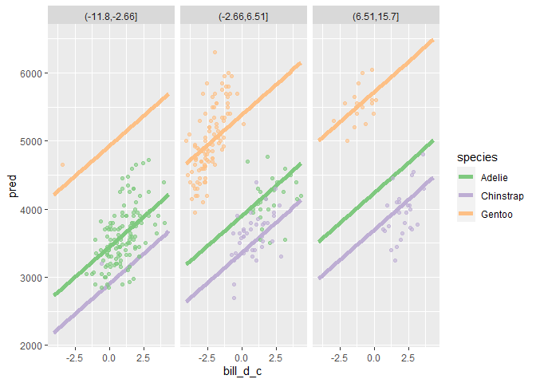

```r
fake_cut_penguins |>
  ggplot(aes(x = bill_d_c, y = pred, colour = species)) +
  geom_line(size = 2) +
  facet_wrap(~cut_bill_len) +
  scale_colour_brewer(type = "qual") +
  geom_point(aes(x = bill_d_c, y = body_mass_g), data = cut_raw_peng, alpha = .6)
```

### interactions and better models

```r
mass_model_interact <- lmer(body_mass_g ~ bill_d_c*bill_l_c + (1 + bill_d_c*bill_l_c|species), data = penguin_centre)
```

```
## boundary (singular) fit: see help('isSingular')
```

```r
summary(mass_model_interact)
```

```
## Linear mixed model fit by REML ['lmerMod']
## Formula: body_mass_g ~ bill_d_c * bill_l_c + (1 + bill_d_c * bill_l_c |
##     species)
##    Data: penguin_centre
##
## REML criterion at convergence: 4917.8
##
## Scaled residuals:
##     Min      1Q  Median      3Q     Max
## -2.3529 -0.6938 -0.0281  0.5965  3.1915
##
## Random effects:
##  Groups   Name              Variance  Std.Dev. Corr
##  species  (Intercept)       1.208e+06 1099.042
##           bill_d_c          6.547e+03   80.914  0.94
##           bill_l_c          4.495e+02   21.201 -0.11 -0.45
##           bill_d_c:bill_l_c 2.935e+01    5.417 -1.00 -0.94  0.11
##  Residual                   1.066e+05  326.512
## Number of obs: 342, groups:  species, 3
##
## Fixed effects:
##                   Estimate Std. Error t value
## (Intercept)       4240.800    635.970   6.668
## bill_d_c           194.103     51.236   3.788
## bill_l_c            46.295     14.507   3.191
## bill_d_c:bill_l_c   -5.915      4.326  -1.367
##
## Correlation of Fixed Effects:
##             (Intr) bll_d_ bll_l_
## bill_d_c     0.862
## bill_l_c    -0.108 -0.488
## bll_d_c:b__ -0.733 -0.593  0.025
## optimizer (nloptwrap) convergence code: 0 (OK)
## boundary (singular) fit: see help('isSingular')
```

```r
# using cut to make a tryptich
cut_raw_peng <- penguin_centre |>
  filter(!is.na(bill_depth_mm)) |>
  mutate(cut_bill_len = cut(bill_l_c, breaks = 3)) |>
  group_by(cut_bill_len) |>
  mutate(mean_bill_len = median(bill_l_c, na.rm = TRUE)) |>
  ungroup()


fake_cut_penguins <-
  data_grid(cut_raw_peng,
            bill_d_c = seq_range(bill_d_c,n = 30),
            nesting(bill_l_c = mean_bill_len,
                    cut_bill_len),
            species)


fake_cut_penguins$pred <- predict(mass_model_interact, newdata = fake_cut_penguins, type = "response")

fake_cut_penguins |>
  count(bill_l_c, cut_bill_len)
```

```
## # A tibble: 3 x 3
##   bill_l_c cut_bill_len      n
##      <dbl> <fct>         <int>
## 1    -5.82 (-11.8,-2.66]    90
## 2     2.28 (-2.66,6.51]     90
## 3     7.53 (6.51,15.7]      90
```

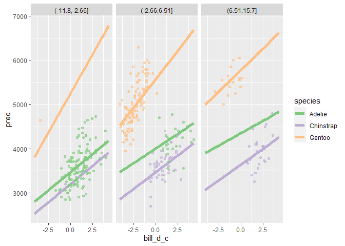

```r
fake_cut_penguins |>
  ggplot(aes(x = bill_d_c, y = pred, colour = species)) +
  geom_line(size = 2) +
  facet_wrap(~cut_bill_len) +
  scale_colour_brewer(type = "qual") +
  geom_point(aes(x = bill_d_c, y = body_mass_g), data = cut_raw_peng, alpha = .6)
```

group mean centered

```r
penguins_gc <- penguins |>
  group_by(species) |>
  mutate(bill_len_gm = mean(bill_length_mm, na.rm = TRUE),
         bill_len_gc = bill_length_mm - bill_len_gm) |>
  ungroup()

bill_model <- lmer(body_mass_g ~ bill_len_gm + bill_len_gc + (1 + bill_len_gc | species), data = penguins_gc)
```

```
## boundary (singular) fit: see help('isSingular')
```

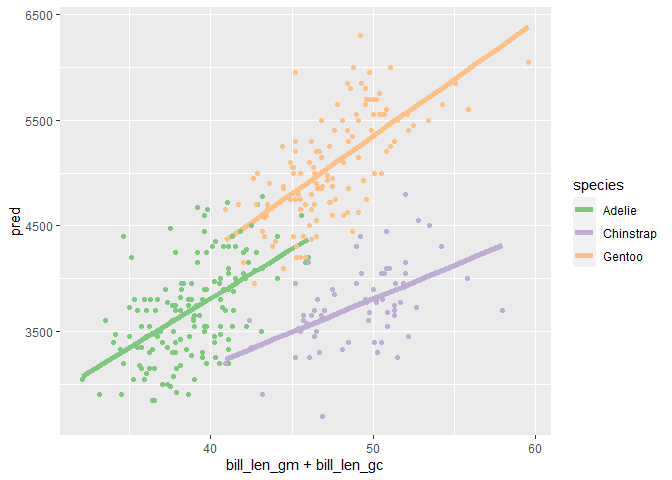

```r
fake_gc_peng <- penguins_gc |>
  nest_by(species, bill_len_gm) |>
  mutate(bill_len_gc = list(seq_range(data$bill_len_gc, n = 12))) |>
  select(-data) |>
  unnest(bill_len_gc) |>
  ungroup()

fake_gc_peng$pred <- predict(bill_model, newdata = fake_gc_peng, type = "response")

fake_gc_peng |>
  ggplot(aes(x = bill_len_gm + bill_len_gc, y = pred, colour = species)) +
  geom_line(size = 2) +
  scale_colour_brewer(type = "qual") +
  geom_point(aes(y = body_mass_g), data = penguins_gc)
```